# EPID 600 Project Template

Malela Werner

Use this template to complete your project throughout the course. Your Final Project presentation in class will be based on the contents of this document. Due dates: - Topic choice: 9/18/15 - List of faculty/staff to be contacted: 10/2/15 - Complete overview with data source to address a specific problem identified: 10/16/15 - Introduction: 11/9/15 - Methods and Results draft: 11/23/15 - Final Document: 12/11/15

### Overview

In this section, give a brief a description of your project and its goal, what data you are using to complete it, and what three faculty/staff in different fields you have spoken to about your project with a brief summary of what you learned from each person. Include a link to your final project GitHub repository.

##### Age related macular degeneration (AMD) is a disease that is prevalent among the elderly, especially after the age of 60 and can lead to blindness. Studying the genetic variations and biological pathways involved in age-related macular degeneration will help further understand the underlying biology of the normal eyes and its regulation and can serve as a guide in implementing new treatment strategies. Using data that has been generated in my research, I analysize RNA-seq results from different tissues of post mortem eyes, retina and retinal pigment epithelium/choroid/sclera tissue (RCS), for differential expression of genes between Normal and AMD eyes. This work is motivated by genome wide association studies (GWAS) which implicated several single nucleotide polymorphisms (SNPs) with AMD. For my current research I am interest in understanding the mechanism through which a gene discovered through GWAS might be implicated in AMD. For the purpose of this report I will refer to this gene as crispr or query gene as the study is still underway. For this work I am in constant communication with my principle investigator, Dr. Dwight Stambolian from the department of ophthalmology, Dr. Mingyao Li from the department of biostatistics and epidemiology, along with other staff members of the kirby center lab: David Cho, Adam Wenocur, Dr. Randy Zauhar and Dr. Lifeng Tian from the center of applied genomics.

[mwerner](https://github.com/mwerner123/Normal-versus-AMD-Peripheral-eyes)

### Introduction

In the first paragraph, describe the problem addressed, its significance, and some background to motivate the problem.

##### Genome wide association studies have revealed single-nucleotide polymorphisms across a wide range of eye disease including macular degeneration. Among these genes CFH, C3 and CFB are known to be involved in age-related macular degeneration. However many other SNPs are in close proximity in genomics regions, which makes it hard to ascertain the causative genes as well as their functional role. Therefore whole transcriptome sequencing through RNA-seq provides an approach for analysing the genetic variations between different layers and tissues of the eyes. The macula with the hightest density of neurons is responsible for central vision, the neurosensory retina is reponsible for processing and sending images to the brain and is a part of the central brain. The retina pigment epithelium and choroidal vasculatur are the main support sustem for the photoreceptors. The marked differences in the tissue functions in the eye might underly different biological processes important in maintaining the health of the photoreceptors and vision. Previous studies in normal eyes (without disease) have shown significant differential expression between the tissues (Retina versus RCS) and the layers of the normal eyes (peripheral versus macular layers). One of the challenges in macular degeneration is defining the role that the genes play in the disease. In this study I am analysing the differential expression between Normal and AMD eyes from whole transcriptome sequencing to determine the genes that might help further understand the biology of the disease. I am also studying the association between a knockout gene of interest and AMD. Our hypothesis is that mutating our gene of interest and studying its effect on global gene expression will provide a list of genes that influence AMD.

In the second paragraph, explain why your problem is interdisciplinary, what fields can contribute to its understanding, and incorporate background related to what you learned from meeting with faculty/staff.

##### Studying the differential expression of the eyes is an interdisciplinary undertaking. Like with other genomic analysis it requires an understanding of the currently known biology of the eye and its significance, a sound statitistical approach to be able to infer changes in expression as well as a constant update on the different software and platforms to undertake the analysis. Through my collaboration with Dr. Stambolian, Dr. Mingyao Li, members of the lab listed above, and of course the Epid600 class, I am able to get feedbacks on guiding approaches for understanding the data.

### Methods

In the first paragraph, describe the data used and general methodological approach. Subsequently, incorporate full R code necessary to retrieve and clean data, and perform analysis. Be sure to include a description of code so that others (including your future self) can understand what you are doing and why.

##### RNA-seq was performed on seven Non-AMD and five AMD post mortem eyes in Retina and RCS tissues as well as two biological replicates of a knockout gene of interest and one wild type sample using paired-end reads. The gene of interest was knockout in a cell line with crispr cas9 guide RNA. The mutants showed sequence deletion and insertion in the exon of interested as well as in promoter region. Preliminary quantitative PCR analysis prior to RNA sequence showed two and 6 fold expression changes between wild type sample and mutants. The RNA-seq data for the knockout presented heres is preliminary as we work to isolated more cell knockouts with crispr cas9 technology to expand our biological replicates. For each resulting fastq file, quality control analysis of the reads was performed using fastqC. Alignment of the reads to hg19 human genome build was performed with the GSNAP alignment software. Further RNA quality control was performed with RNASeQC to check for rate of ribosomal RNA and read duplications. Differential expression of the samples was evaluated using DESeq2 and Cuffdiff. Here I present the results of the Deseq2 analysis and compare them to cuffdiff. DESeq2 uses a count base approach while cuffdiff used a fragment per kilobase per million (FPKM) approach to calculate gene expression. The rational for comparing these two methods to arrive at a list of differentially expressed genes that might be implicated in AMD is that obtaining an agreement between two methods might provide greater credence for the implication of our gene of interest in AMD than just one. As illustrated below, the analysis for differential expression is first provided for eyes (retina then RCS) using DESeq2 followed by a comparison between DESeq2 and Cuffdiff and comparison between crispr gene of interest and eye samples.

# Results

Describe your results and include relevant tables, plots, and code/comments used to obtain them. End with a brief conclusion of your findings related to the question you set out to address.

```r
library('stringr')
library('dplyr')
library('DESeq2')
```

```r
library('reshape2')
library('ggplot2')
library('vsn')
library('xlsx')
library('gplots')
library("pheatmap")
library("genefilter")
library("geneplotter")
```

## DESeq2 Differential gene analysis of Retina data: Normal versus AMD

```r
#Construct DESeq2 Object for Retina data
setwd("C:/Users/malmwamu/Documents/Epid600/Epid600-project/Normal-AMD-PR/")
HTFilesDir <- "C:/Users/malmwamu/Documents/Epid600/Epid600-project/Normal-AMD-PR/"
directory = '.'
HTFiles <- list.files(HTFilesDir, pattern = '*HTseq-reverse.txt')
SampleNO <- str_sub(HTFiles, 1, 4)
SampleNO
```

```
##  [1] "TR01" "TR05" "TR07" "TR09" "TR11" "TR13" "TR15" "TR17" "TR19" "TR21"
## [11] "TR23" "TR25"
```

```r
condition <- c(rep('Normal', 7), rep('AMD', 5))
condition
```

```
##  [1] "Normal" "Normal" "Normal" "Normal" "Normal" "Normal" "Normal"
##  [8] "AMD"    "AMD"    "AMD"    "AMD"    "AMD"
```

```r
libraryName <- paste(condition, "-", SampleNO, sep = "")

metadata <- data.frame(SampleNO = SampleNO, condition = condition, libraryName = libraryName)
metadata = mutate(metadata, countFile =  paste0(metadata$SampleNO, "-HTseq-reverse.txt"))
metadata
```

```
##    SampleNO condition libraryName              countFile
## 1      TR01    Normal Normal-TR01 TR01-HTseq-reverse.txt
## 2      TR05    Normal Normal-TR05 TR05-HTseq-reverse.txt
## 3      TR07    Normal Normal-TR07 TR07-HTseq-reverse.txt
## 4      TR09    Normal Normal-TR09 TR09-HTseq-reverse.txt
## 5      TR11    Normal Normal-TR11 TR11-HTseq-reverse.txt
## 6      TR13    Normal Normal-TR13 TR13-HTseq-reverse.txt
## 7      TR15    Normal Normal-TR15 TR15-HTseq-reverse.txt
## 8      TR17       AMD    AMD-TR17 TR17-HTseq-reverse.txt
## 9      TR19       AMD    AMD-TR19 TR19-HTseq-reverse.txt
## 10     TR21       AMD    AMD-TR21 TR21-HTseq-reverse.txt
## 11     TR23       AMD    AMD-TR23 TR23-HTseq-reverse.txt
## 12     TR25       AMD    AMD-TR25 TR25-HTseq-reverse.txt
```

```r
metadata <- lapply(metadata, as.character)

sampleTable <- data.frame(sampleName = metadata$libraryName, fileName = metadata$countFile, condition = metadata$condition, sampleNO = metadata$SampleNO)

ddsHTSeq<-DESeqDataSetFromHTSeqCount(sampleTable=sampleTable, directory=directory, design=~condition)
ddsHTSeq
```

```
## class: DESeqDataSet
## dim: 57820 12
## metadata(0):
## assays(1): counts
## rownames(57820): ENSG00000000003.10 ENSG00000000005.5 ...
##   ENSGR0000266731.1 ENSGR0000270726.1
## rowRanges metadata column names(0):
## colnames(12): Normal-TR01 Normal-TR05 ... AMD-TR23 AMD-TR25
## colData names(2): condition sampleNO
```

```r
assay(head(ddsHTSeq))
```

```
##                    Normal-TR01 Normal-TR05 Normal-TR07 Normal-TR09
## ENSG00000000003.10        5345        1881        1169        2126
## ENSG00000000005.5           37          31          10           6
## ENSG00000000419.8         6474        2872        1434        3950
## ENSG00000000457.9         8905        4240        1348        6189
## ENSG00000000460.12        3630         867        1521        1698
## ENSG00000000938.8          436         133          98         245
##                    Normal-TR11 Normal-TR13 Normal-TR15 AMD-TR17 AMD-TR19
## ENSG00000000003.10        1991        3639        2032     2795     2710
## ENSG00000000005.5           20          13          14       11       11
## ENSG00000000419.8         3488        5272        3309     3928     1740
## ENSG00000000457.9         4260        5746        4162     6696     3069
## ENSG00000000460.12        1247        2371        1099     2021      617
## ENSG00000000938.8          139         197         208      316       87
##                    AMD-TR21 AMD-TR23 AMD-TR25
## ENSG00000000003.10     3615     4508     2401
## ENSG00000000005.5        42       14       13
## ENSG00000000419.8      3753     2278     2892
## ENSG00000000457.9      5510     4197     4128
## ENSG00000000460.12     1455     1000     1084
## ENSG00000000938.8       394      171      179
```

```r
coldata <- colData(ddsHTSeq)
coldata
```

```
## DataFrame with 12 rows and 2 columns
##             condition sampleNO
##              <factor> <factor>
## Normal-TR01    Normal     TR01
## Normal-TR05    Normal     TR05
## Normal-TR07    Normal     TR07
## Normal-TR09    Normal     TR09
## Normal-TR11    Normal     TR11
## ...               ...      ...
## AMD-TR17          AMD     TR17
## AMD-TR19          AMD     TR19
## AMD-TR21          AMD     TR21
## AMD-TR23          AMD     TR23
## AMD-TR25          AMD     TR25
```

```r
rowRanges(ddsHTSeq)
```

```
## GRangesList object of length 57820:
## $ENSG00000000003.10
## GRanges object with 0 ranges and 0 metadata columns:
##    seqnames    ranges strand
##       <Rle> <IRanges>  <Rle>
##
## $ENSG00000000005.5
## GRanges object with 0 ranges and 0 metadata columns:
##      seqnames ranges strand
##
## $ENSG00000000419.8
## GRanges object with 0 ranges and 0 metadata columns:
##      seqnames ranges strand
##
## ...
## <57817 more elements>
## -------
## seqinfo: no sequences
```

```r
mcols(rowRanges(ddsHTSeq))
```

```
## DataFrame with 57820 rows and 0 columns
```

```r
#Exploratory data analysis of Retina data: Normal versus AMD eyes

#Trim genes with low read counts
ddsHTSeq<- ddsHTSeq[rowSums(counts(ddsHTSeq)) > 1, ]
nrow(ddsHTSeq)
```

```
## [1] 42242
```

```r
head(rownames(ddsHTSeq))
```

```
## [1] "ENSG00000000003.10" "ENSG00000000005.5"  "ENSG00000000419.8"
## [4] "ENSG00000000457.9"  "ENSG00000000460.12" "ENSG00000000938.8"
```

```r
#estimate size factors to account for differences in sequencing depth.
ddsHTSeq <- estimateSizeFactors(ddsHTSeq)
sizeFactors(ddsHTSeq)
```

```
## Normal-TR01 Normal-TR05 Normal-TR07 Normal-TR09 Normal-TR11 Normal-TR13
##   2.1498279   0.8523002   0.6016721   0.9998148   0.8484597   1.4070119
## Normal-TR15    AMD-TR17    AMD-TR19    AMD-TR21    AMD-TR23    AMD-TR25
##   0.8552126   1.3215914   0.6309369   1.2792909   0.9941882   0.8881816
```

```r
colSums(counts(ddsHTSeq))
```

```
## Normal-TR01 Normal-TR05 Normal-TR07 Normal-TR09 Normal-TR11 Normal-TR13
##   351142152   146213209   113404787   163971602   136525622   239039219
## Normal-TR15    AMD-TR17    AMD-TR19    AMD-TR21    AMD-TR23    AMD-TR25
##   142457877   276596889   106421088   205183130   157978522   153294550
```

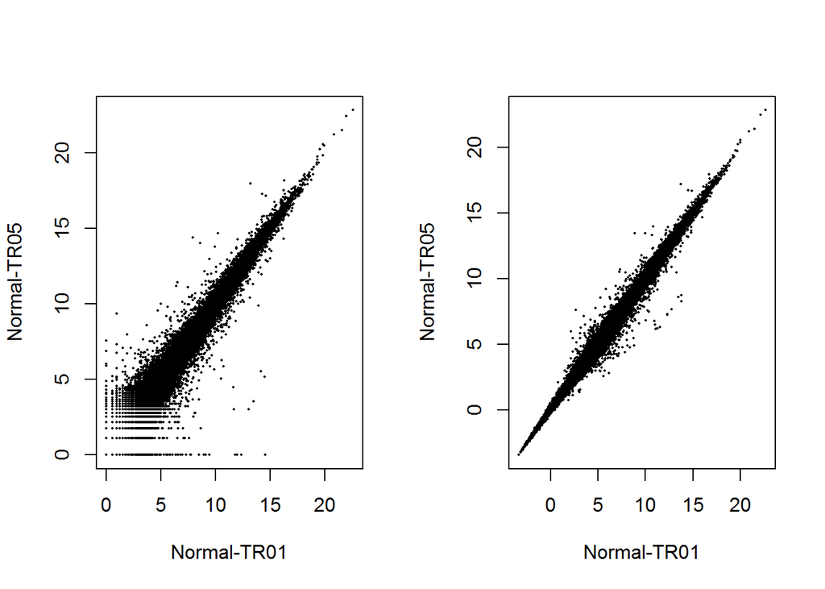

```r
##Transform data with rlog (regularized-logarithm transformation) to make data more homoskedastic
rld <- rlog(ddsHTSeq)
par( mfrow = c( 1, 2 ) )
plot(log2(counts(ddsHTSeq, normalized=TRUE)[,1:2] + 1),
     pch=16, cex=0.3)
plot(assay(rld)[,1:2],
     pch=16, cex=0.3)
```

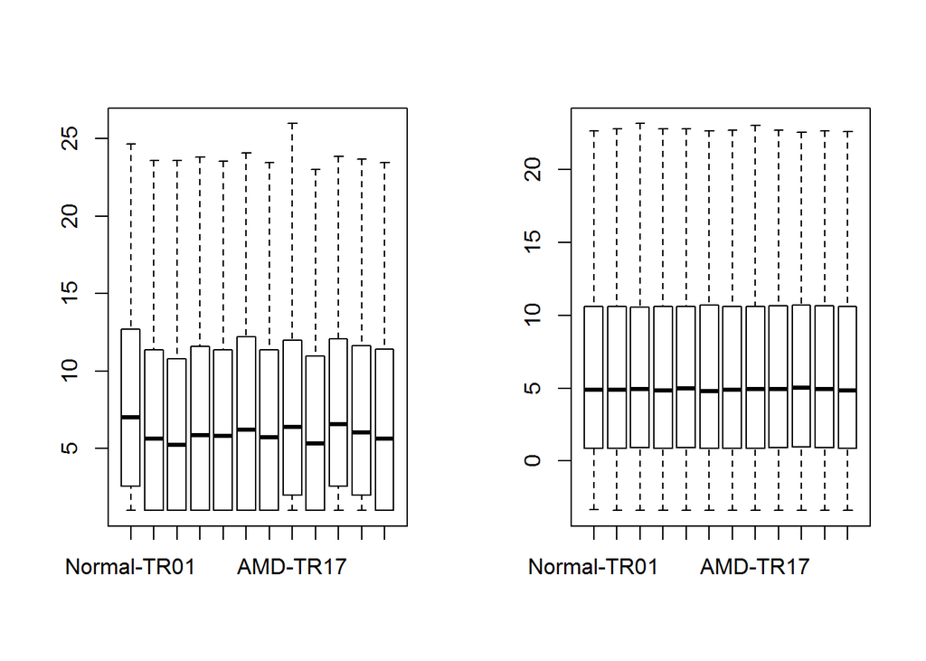

```r
boxplot(log2(counts(ddsHTSeq))+1) #not normalized
boxplot(assay(rld)) #normalized data
```

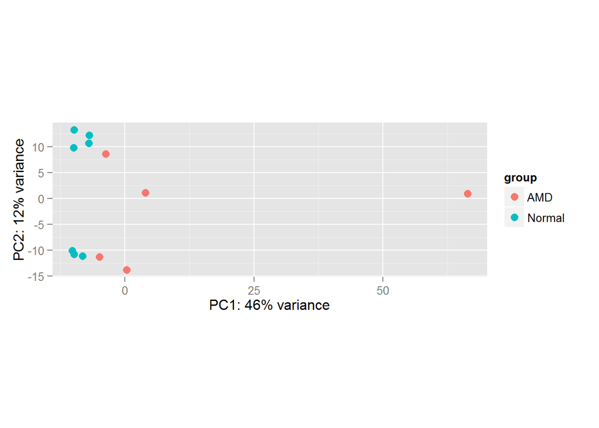

```r
#PCA to look at variation between samples.
plotPCA(rld, intgroup="condition")
```

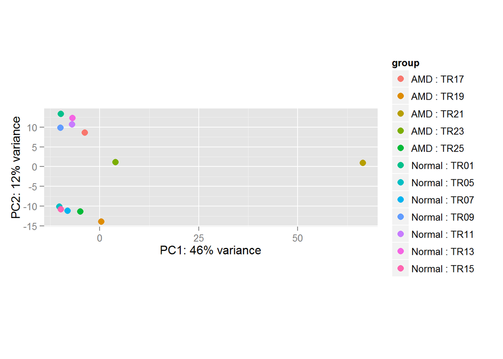

```r
plotPCA(rld, intgroup=c("condition", "sampleNO"))
```

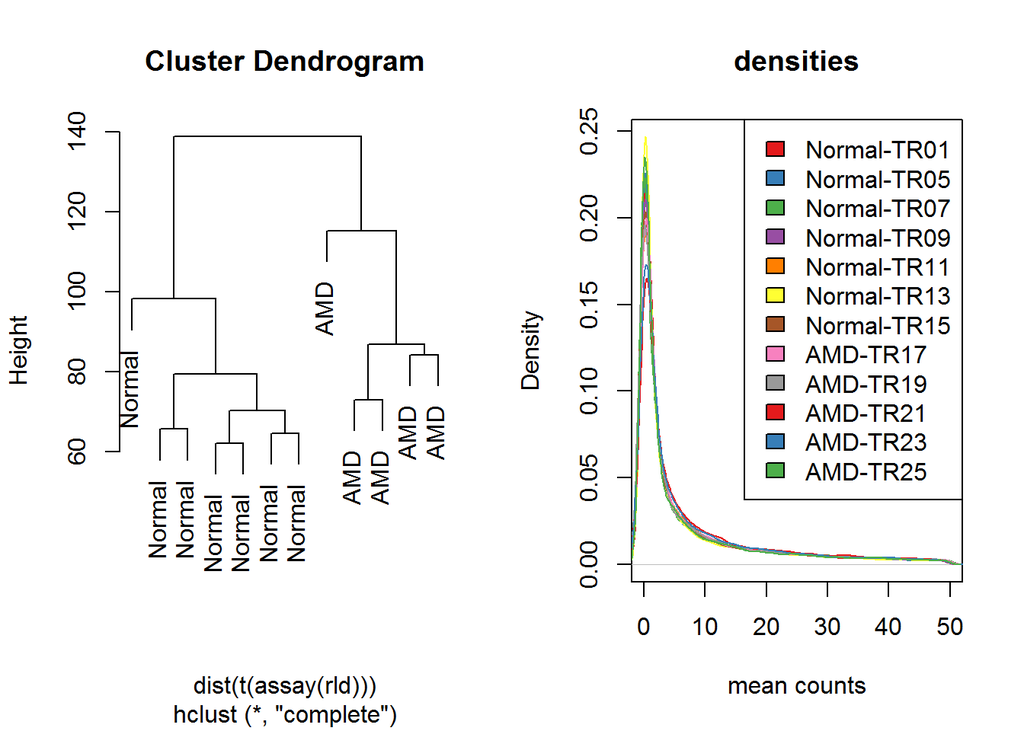

```r
#dendrogram cluster
plot(hclust(dist(t(assay(rld)))), labels=colData(rld)$condition)

#compare density distribution of data
multidensity(counts(ddsHTSeq, normalized = T), xlab='mean counts', xlim=c(0,50), pch=16, cex=0.3)
```

```r
###Perform differential gene expression on Retina data: Normal versus AMD eyes

design(ddsHTSeq) <- ~condition
levels(ddsHTSeq$condition)
```

```
## [1] "AMD"    "Normal"
```

```r
ddsHTSeq$condition <- relevel(ddsHTSeq$condition, "AMD") #The reference condition was chosen as AMD instead of Normal in order to match the direction of fold changes in the cuffdiff file in later comparison between DESeq2 and cuffdiff.
levels(ddsHTSeq$condition)
```

```
## [1] "AMD"    "Normal"
```

```r
ddsHTSeq <- DESeq(ddsHTSeq)
```

```
## -- replacing outliers and refitting for 942 genes
## -- DESeq argument 'minReplicatesForReplace' = 7
## -- original counts are preserved in counts(dds)
```

```r
res <- results(ddsHTSeq)
head(res)
```

```
## log2 fold change (MAP): condition Normal vs AMD
## Wald test p-value: condition Normal vs AMD
## DataFrame with 6 rows and 6 columns
##                      baseMean log2FoldChange     lfcSE        stat
##                     <numeric>      <numeric> <numeric>   <numeric>
## ENSG00000000003.10 2712.08074    -0.50127880 0.1871637 -2.67829068
## ENSG00000000005.5    17.72441     0.01531003 0.3825144  0.04002473
## ENSG00000000419.8  3221.11500     0.28990059 0.1530402  1.89427704
## ENSG00000000457.9  4552.16464    -0.03580626 0.1994619 -0.17951427
## ENSG00000000460.12 1436.89430     0.44658043 0.2054569  2.17359617
## ENSG00000000938.8   197.69564    -0.17006327 0.2182188 -0.77932440
##                         pvalue       padj
##                      <numeric>  <numeric>
## ENSG00000000003.10 0.007399897 0.04830904
## ENSG00000000005.5  0.968073414 0.98551631
## ENSG00000000419.8  0.058188247 0.20181733
## ENSG00000000457.9  0.857533916 0.93805542
## ENSG00000000460.12 0.029735476 0.12772544
## ENSG00000000938.8  0.435788643 0.67389440
```

```r
summary(res)
```

```
##
## out of 42238 with nonzero total read count
## adjusted p-value < 0.1
## LFC > 0 (up)     : 2918, 6.9%
## LFC < 0 (down)   : 3869, 9.2%
## outliers [1]     : 789, 1.9%
## low counts [2]   : 8857, 21%
## (mean count < 1)
## [1] see 'cooksCutoff' argument of ?results
## [2] see 'independentFiltering' argument of ?results
```

```r
#Display #genes with adjusted p-value < 0.05
res2 <- results(ddsHTSeq, alpha = 0.05)
head(res2)
```

```
## log2 fold change (MAP): condition Normal vs AMD
## Wald test p-value: condition Normal vs AMD
## DataFrame with 6 rows and 6 columns
##                      baseMean log2FoldChange     lfcSE        stat
##                     <numeric>      <numeric> <numeric>   <numeric>
## ENSG00000000003.10 2712.08074    -0.50127880 0.1871637 -2.67829068
## ENSG00000000005.5    17.72441     0.01531003 0.3825144  0.04002473
## ENSG00000000419.8  3221.11500     0.28990059 0.1530402  1.89427704
## ENSG00000000457.9  4552.16464    -0.03580626 0.1994619 -0.17951427
## ENSG00000000460.12 1436.89430     0.44658043 0.2054569  2.17359617
## ENSG00000000938.8   197.69564    -0.17006327 0.2182188 -0.77932440
##                         pvalue       padj
##                      <numeric>  <numeric>
## ENSG00000000003.10 0.007399897 0.04830904
## ENSG00000000005.5  0.968073414 0.98551631
## ENSG00000000419.8  0.058188247 0.20181733
## ENSG00000000457.9  0.857533916 0.93805542
## ENSG00000000460.12 0.029735476 0.12772544
## ENSG00000000938.8  0.435788643 0.67389440
```

```r
table(res2$padj < 0.05)
```

```
##
## FALSE  TRUE
## 27516  5080
```

```r
summary(res2)
```

```
##
## out of 42238 with nonzero total read count
## adjusted p-value < 0.05
## LFC > 0 (up)     : 2138, 5.1%
## LFC < 0 (down)   : 2942, 7%
## outliers [1]     : 789, 1.9%
## low counts [2]   : 8857, 21%
## (mean count < 1)
## [1] see 'cooksCutoff' argument of ?results
## [2] see 'independentFiltering' argument of ?results
```

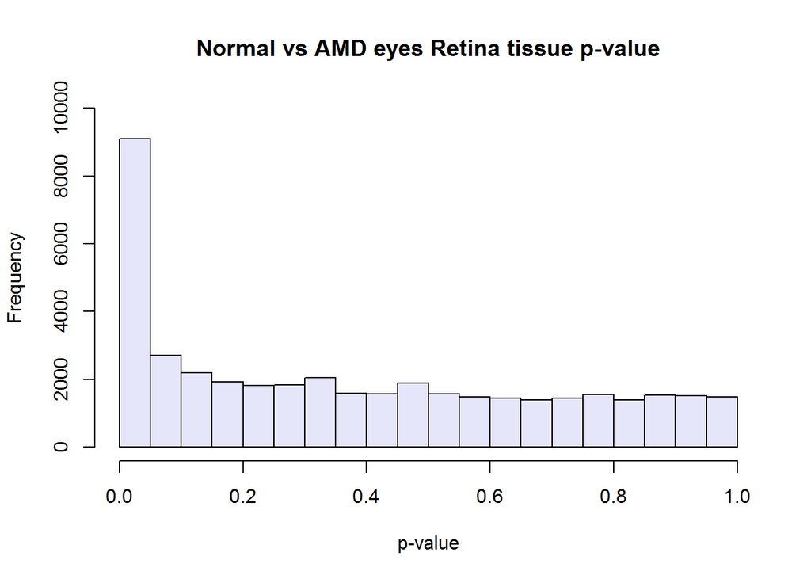

```r
####Plot differential gene expression for Retina data: Normal versus AMD

#histogram distribution of pvalues and FDR adjucted p-values:
hist(res$pvalue, col = "lavender", ylim = c(0,10000), main = "Normal vs AMD eyes Retina tissue p-value", xlab = "p-value")
```

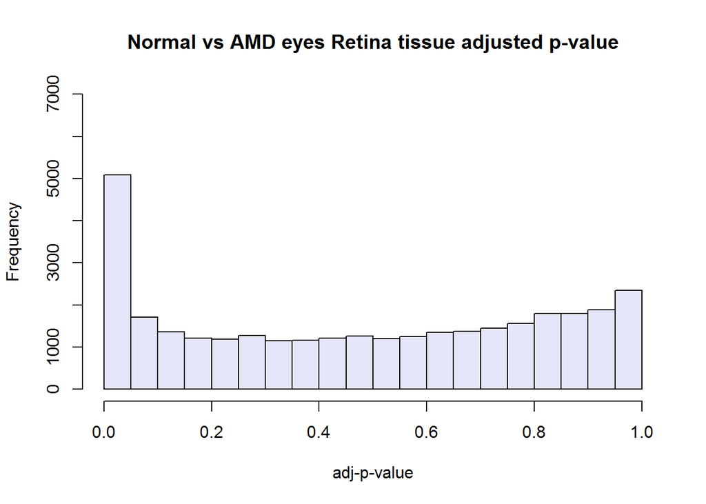

```r
hist(res$padj, col = "lavender", ylim = c(0,7000), main = "Normal vs AMD eyes Retina tissue adjusted p-value", xlab = "adj-p-value")
```